# Assignment 2

- Also plot the scores, zoom in to short time intervals and look at periodicity

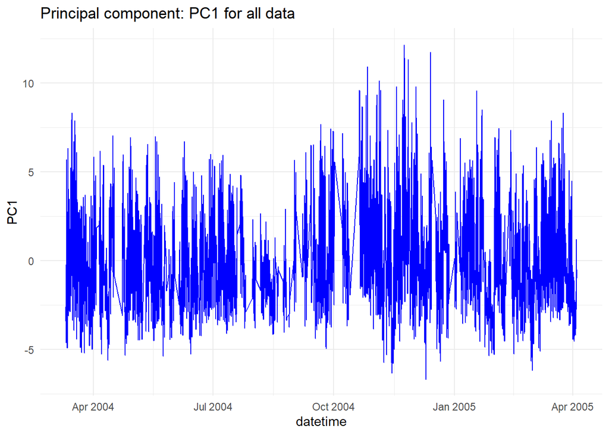

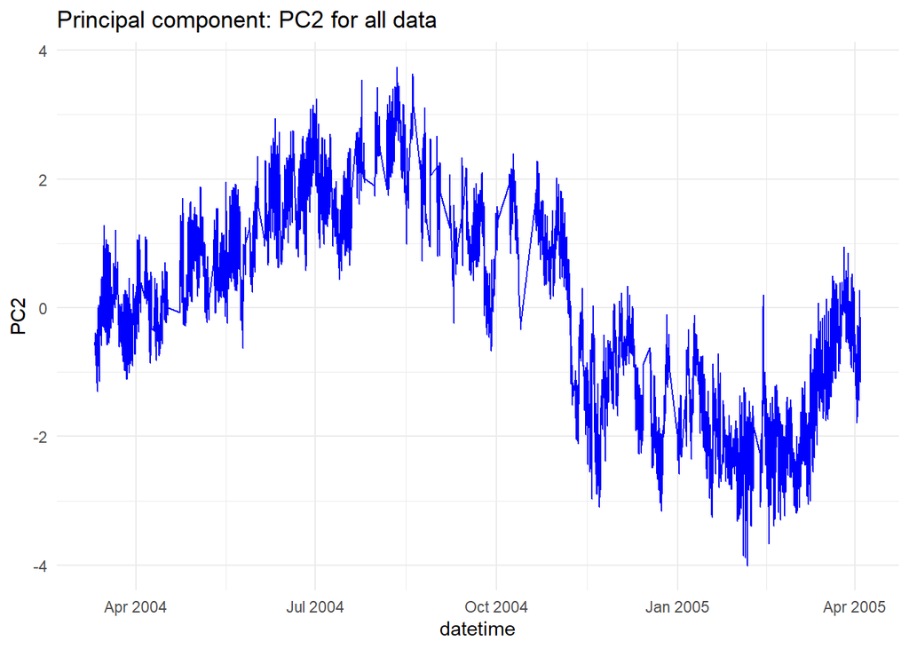

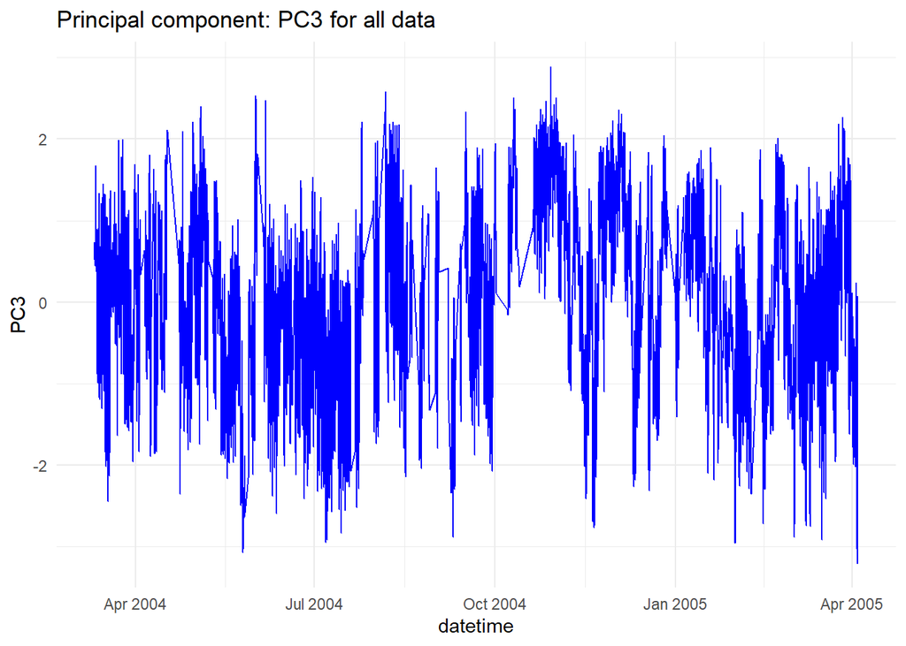

```r
pc_scores <- pc_cleaned$x[, 1:3] # Getting pc values for all rows.
pc_scores <- as.data.frame(pc_scores)
pc_scores$datetime <- tsib_df_no_NMHC$datetime

for (col in colnames(pc_scores[, names(pc_scores) != "datetime"])) {

  p <- ggplot() +
    geom_line(data = pc_scores, aes_string(x = "datetime", y = col), color = "blue") +
    labs(title = paste("Principal component:", col, "for all data"),
         y = col) +
    theme_minimal()
  print(p)}
```

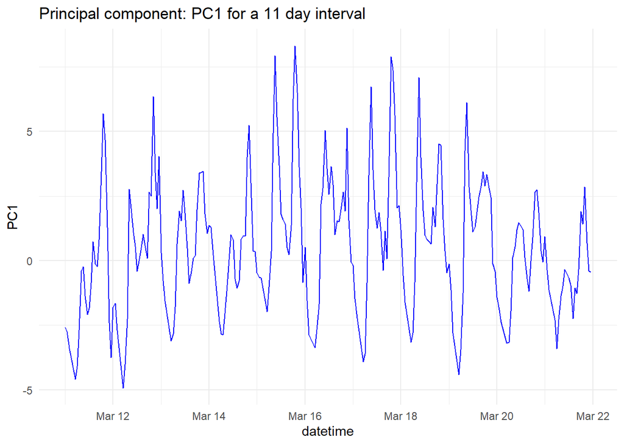

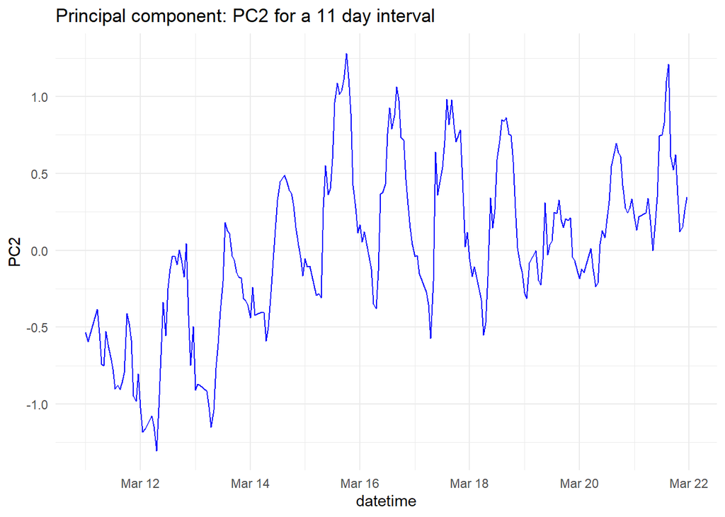

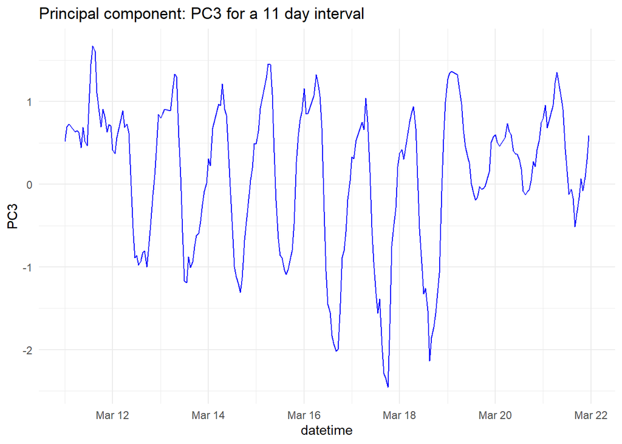

```r
pc_scores <- pc_cleaned$x[, 1:3] # Getting pc values for all rows.
pc_scores <- as.data.frame(pc_scores)
pc_scores$datetime <- tsib_df_no_NMHC$datetime

filtered_scores <- pc_scores %>%
  filter(datetime >= "2004-03-11 00:00:00" & datetime <= "2004-03-22 00:00:00")
#Print PC1, PC2 and PC3 scores
for (col in colnames(filtered_scores[, names(filtered_scores) != "datetime"])) {

  p <- ggplot() +
    geom_line(data = filtered_scores, aes_string(x = "datetime", y = col), color = "blue") +
    labs(title = paste("Principal component:", col, "for a 11 day interval"),
         y = col) +
    theme_minimal()
  print(p)}
```

- Can you interpret certain PCs?

PC1 clearly captures some daily periodicity, but also PC2 and PC3 does the same. In the short time span of 11 days, PC2 seem to have some rising trend, but is likely caused by the yearly periodicity, which is rising in march.

# Task 2: STL and correlation on weather data

## Part A: Data collection for a single station

Based on material from the lectures, write an R function that can obtain a daily average temperature series for a meteorological station from the Norwegian Met Institute’s Frost service. The function shall return a tsibble.

```r
# Used https://frost.met.no/r_example.html as a reference


library(jsonlite)
library(tidyr)


#function
get_station_data <- function(station_id) {

client_id <- "df073266-cbaf-4903-a3c2-4ffc75fcd21b"
# Define andpoint and parameters
endpoint <- paste0("https://", client_id, "@frost.met.no/observations/v0.jsonld")
elements <- 'mean(air_temperature P1D)'
referenceTime <- '1950-01-01/2024-09-01'
timeoffsets <- 'PT0H'

# Build the URL to Frost
url <- paste0(
    endpoint, "?",
    "sources=", station_id,
    "&referencetime=", referenceTime,
    "&elements=", elements,
    "&timeoffsets=", timeoffsets
)
# Issue an HTTP GET request and extract JSON data
xs <- try(fromJSON(URLencode(url),flatten=T))

# Check if the request worked, print out any errors
if (class(xs) != 'try-error') {
    df <- unnest(xs$data, cols=everything())
    print("Data retrieved from frost.met.no!")
} else {
    print("Error: the data retrieval was not successful!")
}
df <- df[, c("referenceTime", "value")]
df$referenceTime <- as.Date(df$referenceTime)


return(as_tsibble(df, index = "referenceTime"))
}
```

```r
raw_df <- get_station_data("SN17850")
```

```
## [1] "Data retrieved from frost.met.no!"
```

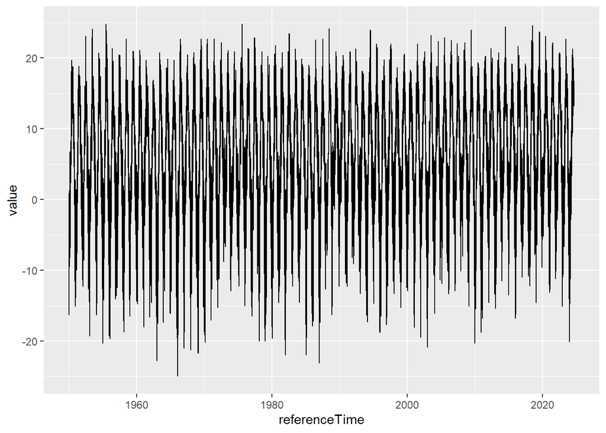

```r
ggplot(raw_df, aes(x=referenceTime, y=value)) + geom_line()
```

## Part B: Data preparation for a single station

- Identify gaps in the time series.

```r
library(tidyverse)
```

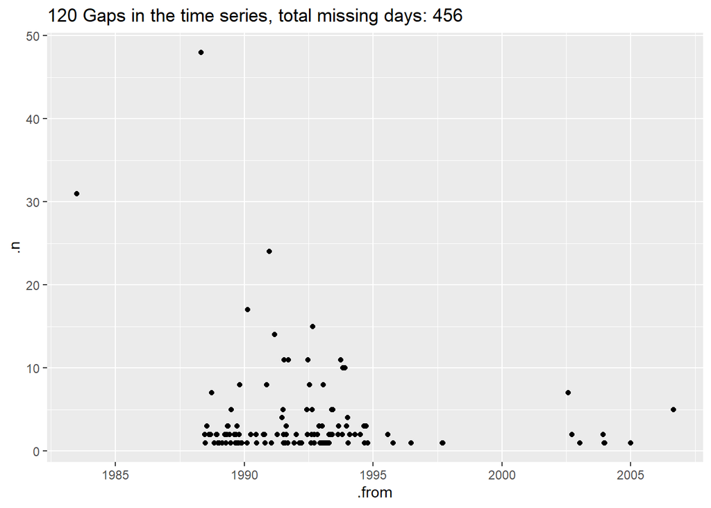

```r
# find gaps
gaps <- raw_df %>%
  count_gaps(.full = TRUE)

#plot gaps
ggplot(gaps, aes(x=.from, y=.n)) + geom_point() + ggtitle(paste0(length(gaps$.n), " Gaps in the time series, total missing days: ", sum(gaps$.n)))
```

- Assume that gaps up to 31 days are acceptable. Find the earliest date in the time series such that all following data have no gaps longer than 31 days. Limit the time series to this.

```r
# find the earliest date in the time series such that all following data have no gaps longer than 31 days
gaps <- gaps %>%
  filter(.n > 31)

raw_df <- raw_df %>%
  filter(referenceTime >= max(gaps$.to))
```

- Create a regular time series by filling gaps in the tsibble with n/a-s.

```r
# Create a regular time series by filling gaps in the tsibble with n/a-s.
df_full <- fill_gaps(raw_df, .full = TRUE)
```

- Impute values for the n/a-s. Justify your choice of imputation method.

```r
library(imputeTS)
# Impute values
df <- df_full %>% na_interpolation()
```

- You should now have a regular time series with only numeric values.

```r
sum(is.na(df$value))
```

```
## [1] 0
```

- Remove all data for 29 February so all years have data for exactly 365 days.

```r
# Remove every 29. of February
df <- df %>% filter(!(month(referenceTime) == 2 & day(referenceTime) == 29))
```

- Combine all this code into a function for re-use later. The function should receive the original tsibble from part A as input and return a new tsibble.

```r
prepare_station_data <- function(raw_df) {
  # find gaps
  gaps <- raw_df %>%
    count_gaps(.full = TRUE)

  # find the earliest date in the time series such that all following data have no gaps longer than 31 days
  gaps <- gaps %>%
    filter(.n > 31)

  if (nrow(gaps) > 0) {
    raw_df <- raw_df %>%
      filter(referenceTime >= max(gaps$.to))
  }

  # Create a regular time series by filling gaps in the tsibble with n/a-s.
  df_full <- fill_gaps(raw_df, .full = TRUE)

  # Impute values
  df <- df_full %>% na_interpolation()

  # Remove every 29. of February
  df <- df %>% filter(!(month(referenceTime) == 2 & day(referenceTime) == 29))

  return(df)
}
```

## Part C: Exploratory analysis for a single station

- Plot the temperature data as function of time

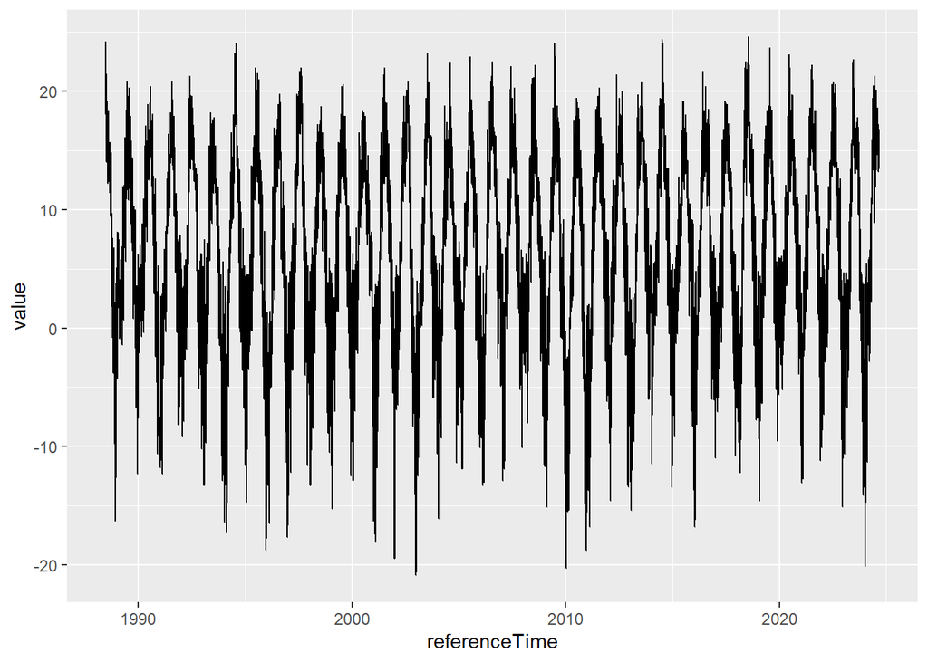

```r
ggplot(df, aes(x=referenceTime, y=value)) + geom_line()
```

- Create density plots of original data and data with imputed values

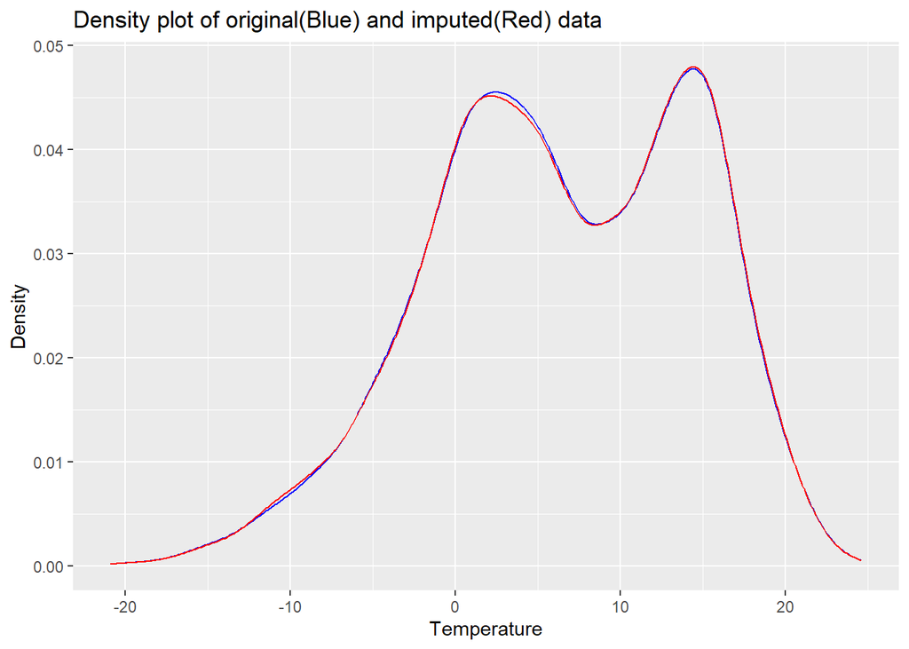

```r
ggplot() + geom_density(raw_df, mapping = aes(x=value, color="blue"), color="blue") + geom_density(df, mapping = aes(x=value, colour = "red"), color="red") + labs(title="Density plot of original(Blue) and imputed(Red) data", x="Temperature", y="Density")
```

- Turn the temperature data into a timeseries (ts) object

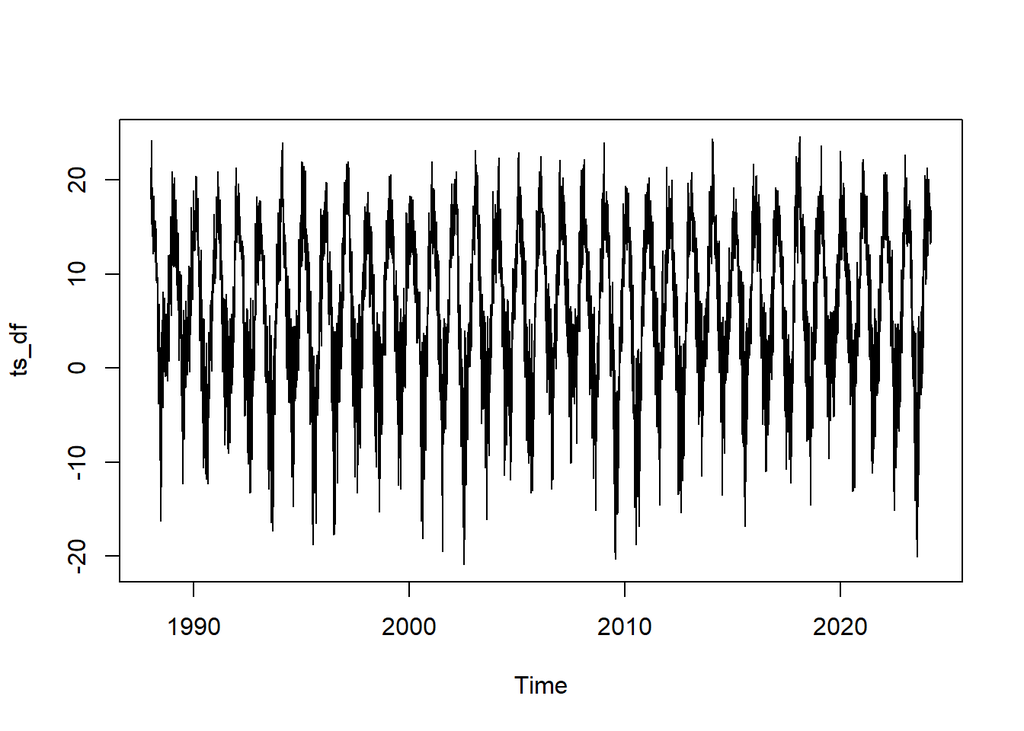

```r
ts_df <- ts(df$value, start=c(year(min(df$referenceTime)), month(min(df$referenceTime)), day(min(df$referenceTime))), frequency=365)
plot(ts_df)
```

- Plot the autocorrelation function for lags up to 5.5 years; describe and discuss your observations

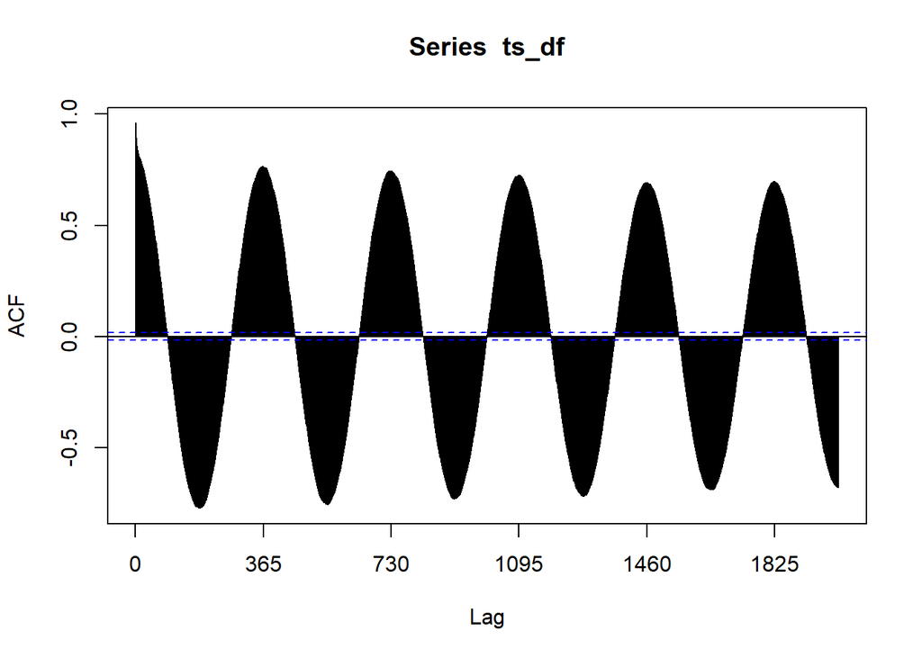

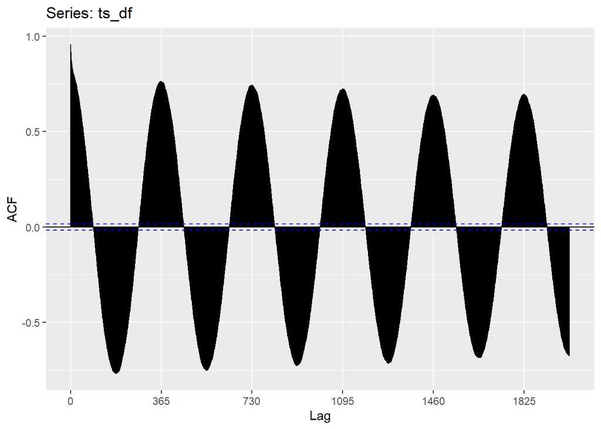

```r
library(forecast)
library(ggfortify)

autoplot(Acf(ts_df, lag.max=365*5.5))
```

There is a clear positive correlation for a year, and clear negative for half a year. The data has periodicity.

- Also plot the ACF only for short lags, up to four weeks

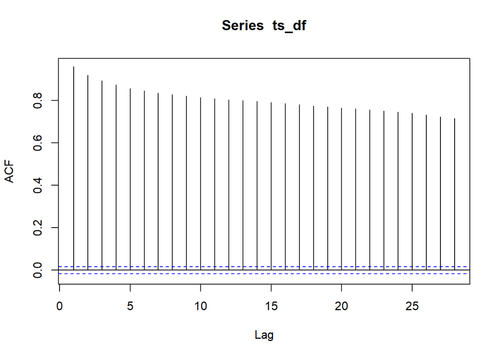

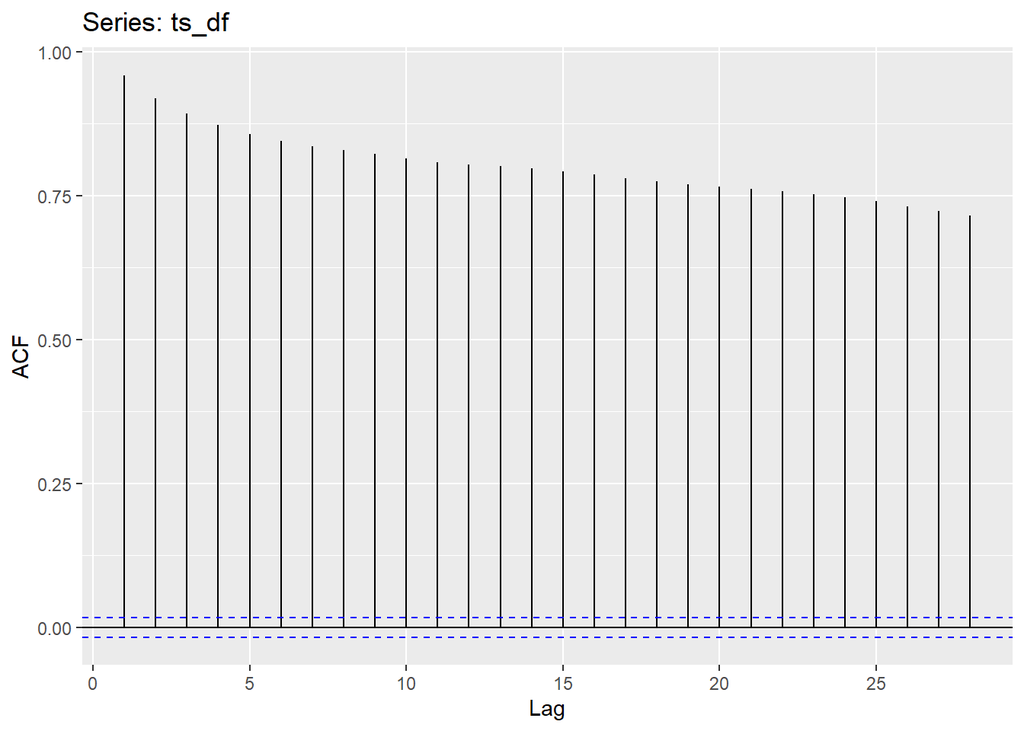

```r
autoplot(Acf(ts_df, lag.max=28))
```

Falling trend in relevancy, but after 4 weeks it is still pretty high. So within approximately a month, the dataset is still correlated.

- Select some days distributed throughout the year and plot temperature as function of year for, e.g., 1 October, as a scatter plot. This plot can be useful to choose the seasonality window later (see Figs 7 and 8 in Cleveland et al, 1990)

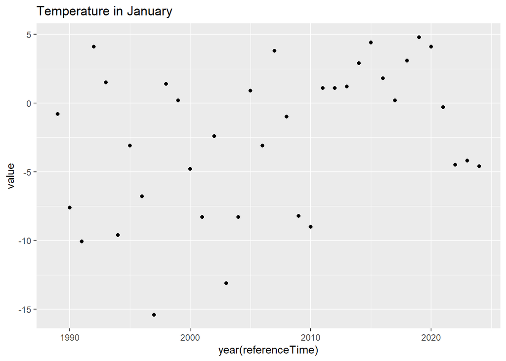

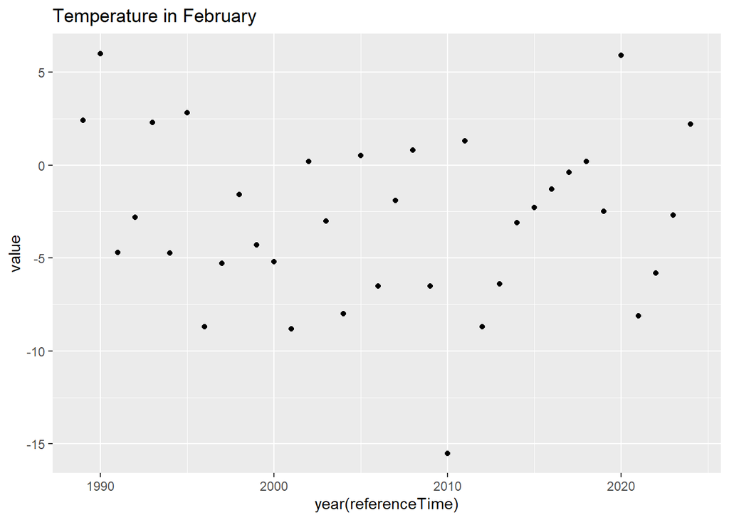

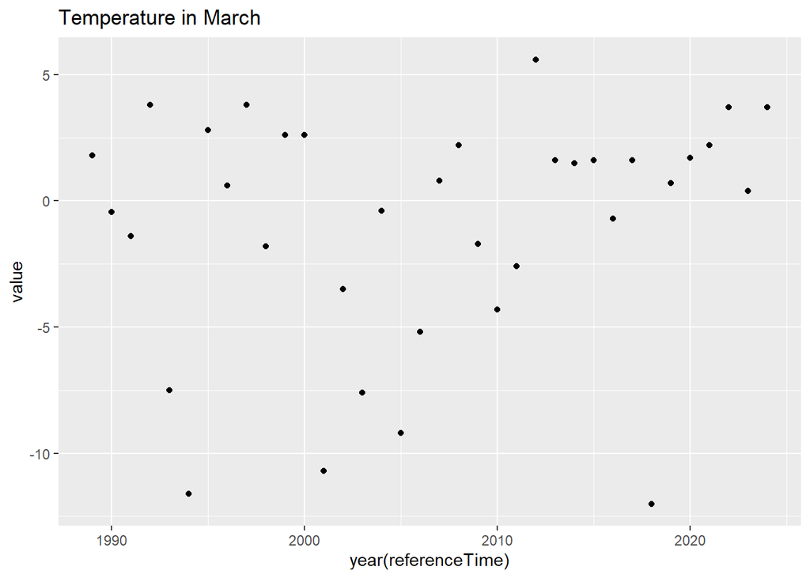

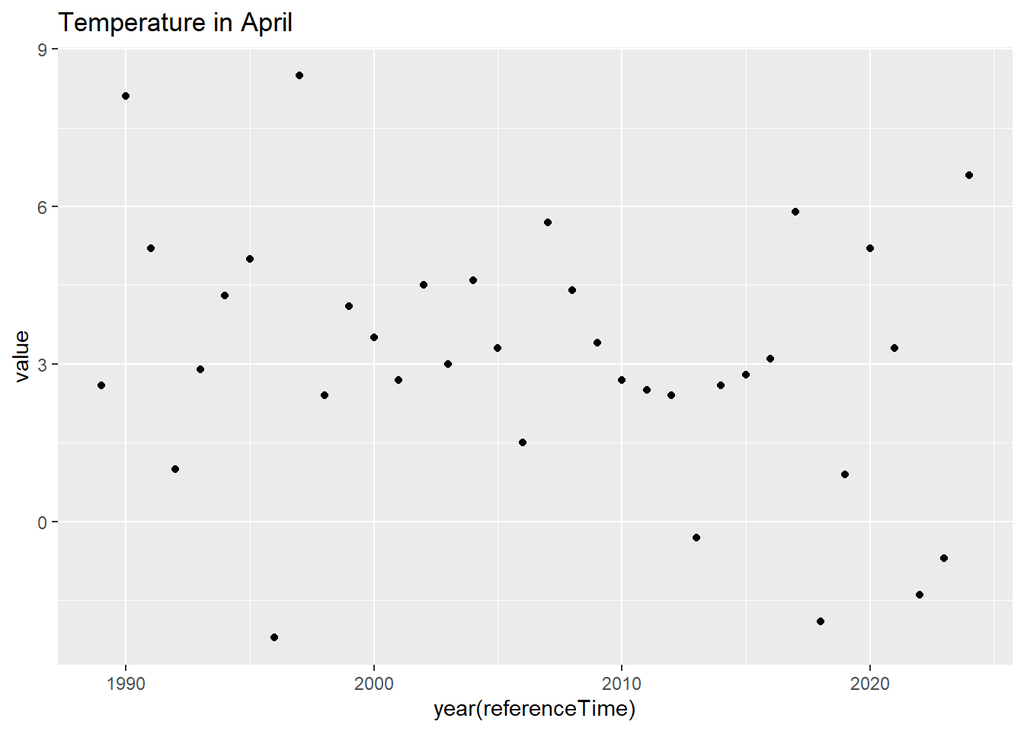

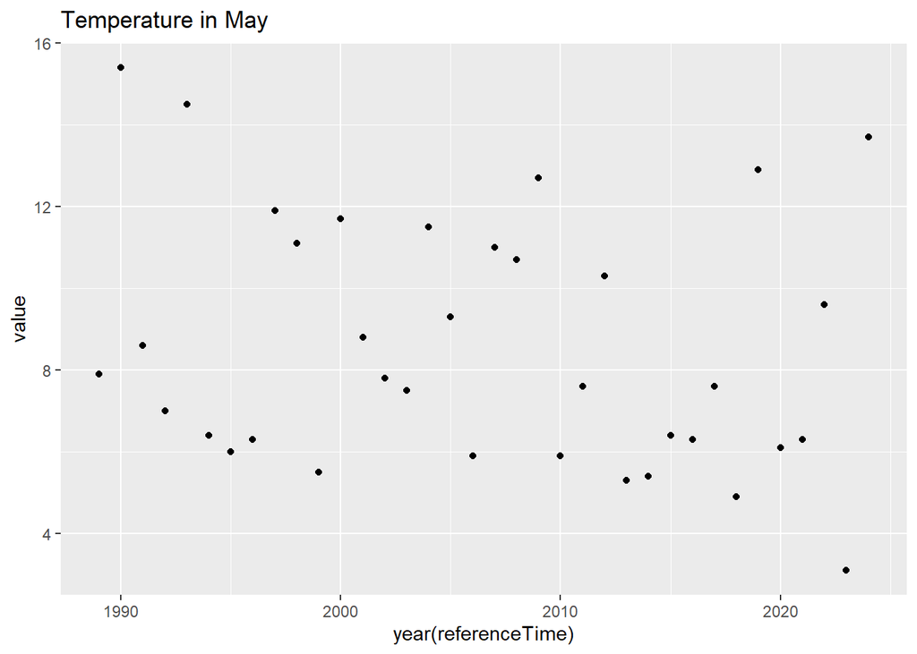

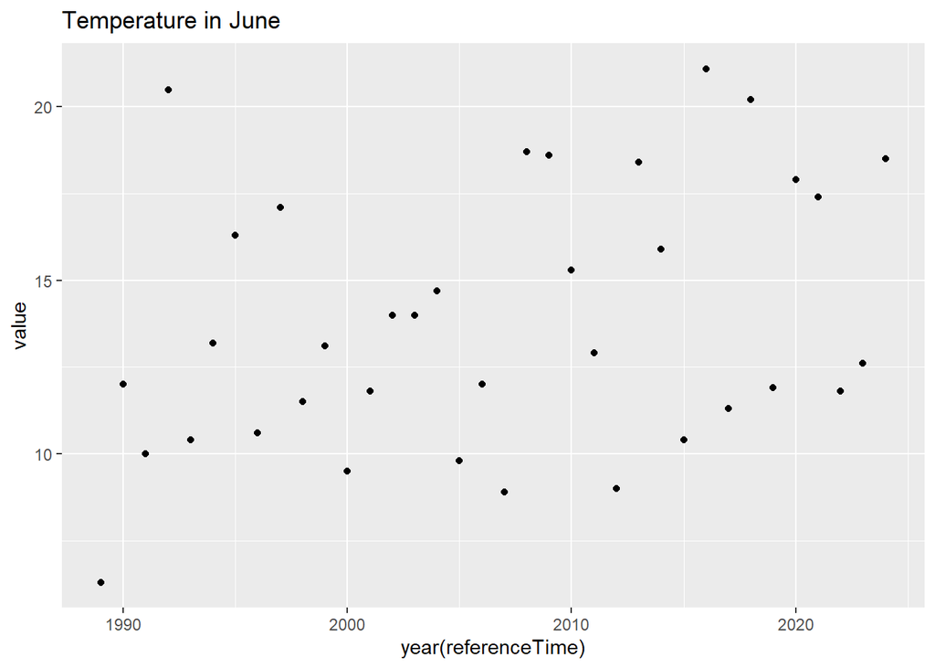

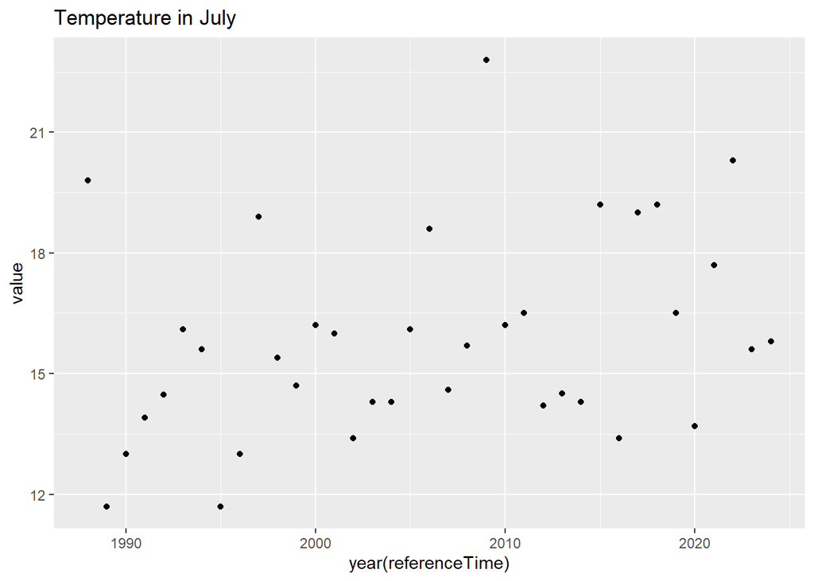

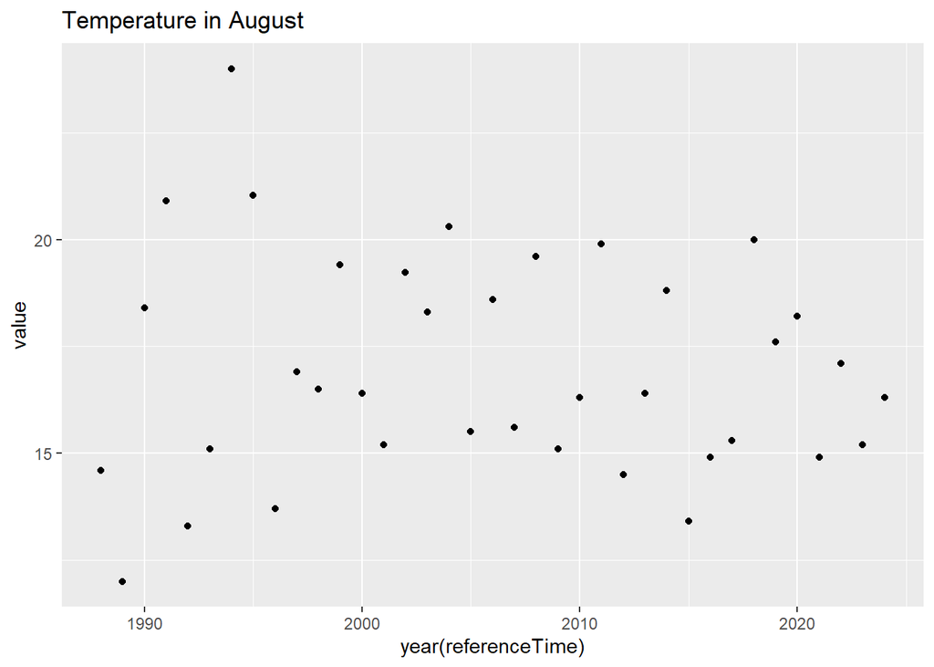

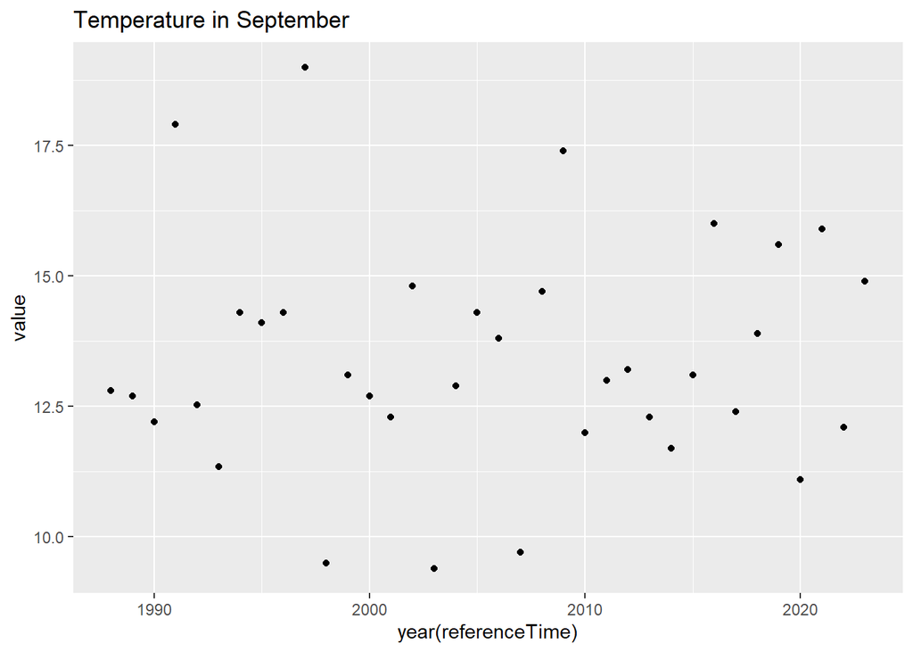

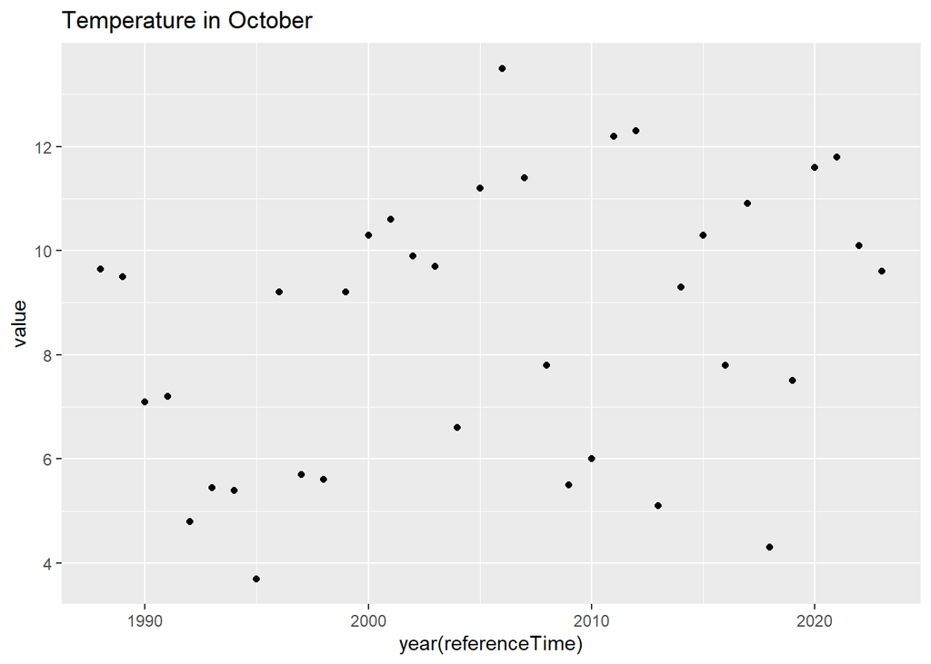

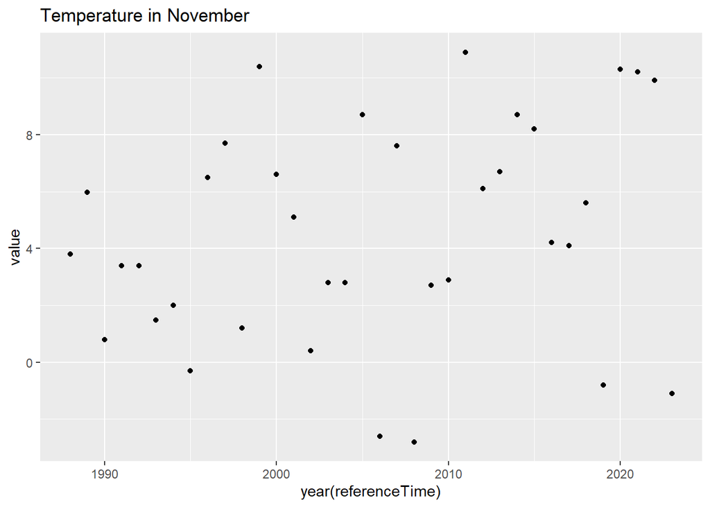

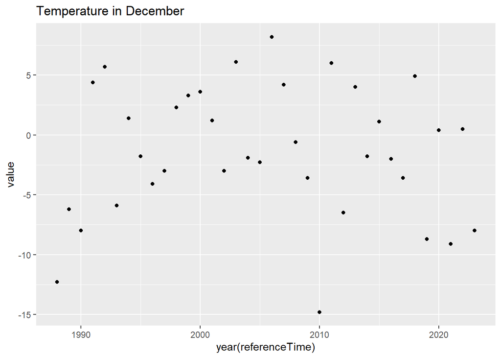

```r
# Select some days distributed throughout the year
for (month in 1:12){
  day <- 1
  df_day <- df %>% filter(month(referenceTime) == month & day(referenceTime) == day)
  p <- ggplot(df_day, aes(x=year(referenceTime), y=value)) + geom_point() + geom_abline() + ggtitle(paste0("Temperature in ", month.name[month]))
  print(p)

}
```

First of each month chosen, showing that there is variance for each year. This indicates that a large trend window might be needed in the STL.

## Part D: STL analysis

- Perform STL on the data. Explore different values for the seasonality and trend windows (remember that we want to look at trends over many years!), the choice between robust STL or not, and possibly the lowpass filter window. Describe your observations. It might be interesting to look at the ACF of the remainder in the STL result.

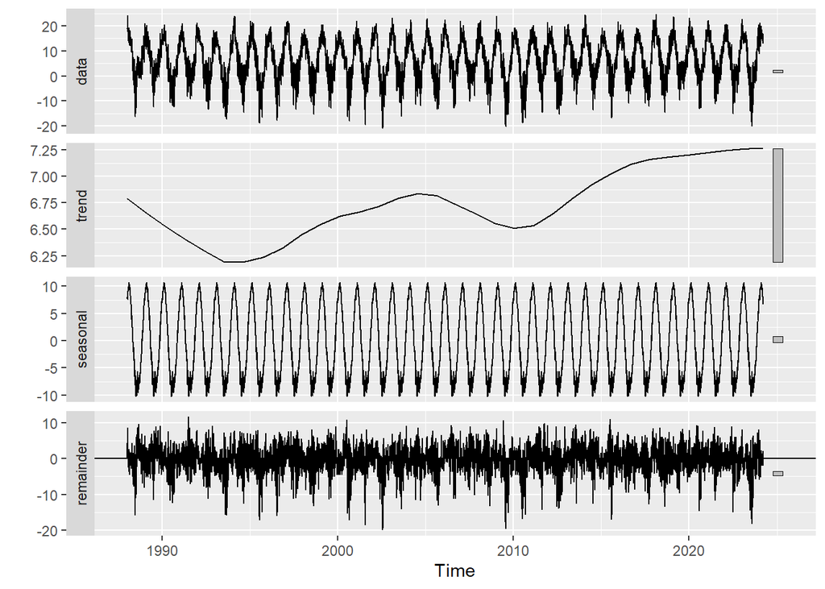

```r
stl_as <- stl(ts_df, s.window="periodic", t.window = 11*365, robust=TRUE)
autoplot(stl_as)
```

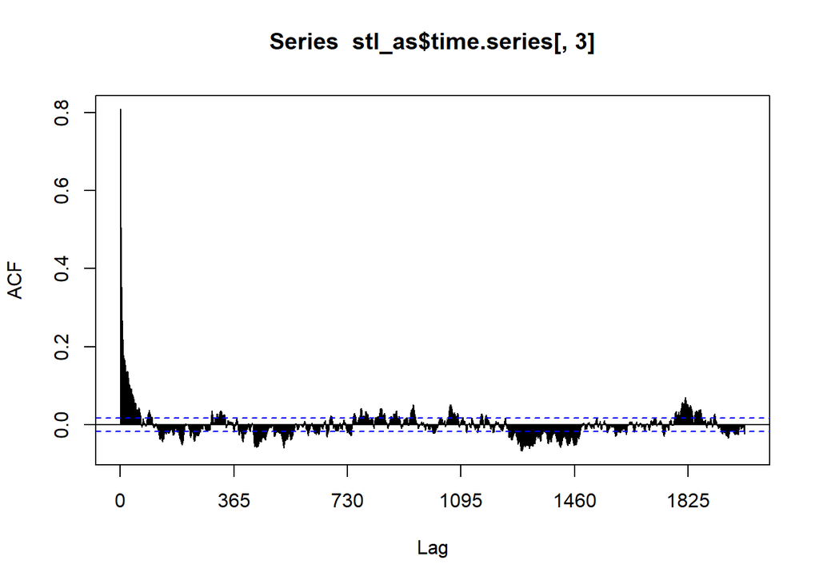

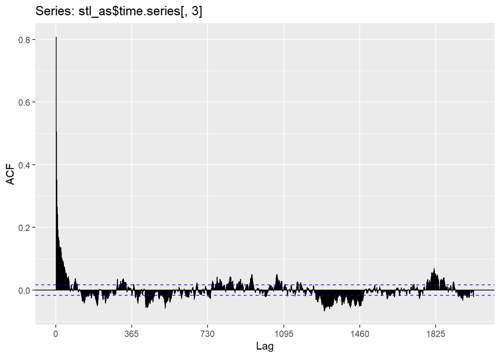

```r
autoplot(Acf(stl_as$time.series[,3], lag.max=365*5.5))
```

The ACF for the noise shows that there is not alot of seasonal dependency in the remainder. Indicating that the STL is catching the trend and seasonailty well.

- Consult the original STL paper by Cleveland et al. (1990) for suggestions on how to choose STL parameters.
- Based on your analysis, can you suggest a set of STL parameters to use for further work?

We suggest a periodic time window, and an 11 year span for the trend.

## Part E: Multiple station analysis

- Obtain data from eight more stations. Two should be in the same part of Norway as the station from part A; then choose three stations each from two other parts of Norway. Data should cover several decades at least, so look for stations with long series.

```r
# Akershus og Østfold
as_df <- df
sarpsborg_df <- get_station_data("SN3190")
```

```
## [1] "Data retrieved from frost.met.no!"
```

```r
sarpsborg_df <- prepare_station_data(sarpsborg_df)
gardemoen_df <- get_station_data("SN4780")
```

```
## [1] "Data retrieved from frost.met.no!"
```

```r
gardemoen_df <- prepare_station_data(gardemoen_df)

# Vestlandet
bergen_df <- get_station_data("SN50540")
```

```
## [1] "Data retrieved from frost.met.no!"
```

```r
bergen_df <- prepare_station_data(bergen_df)
haugesund_df <- get_station_data("SN47260")
```

```
## [1] "Data retrieved from frost.met.no!"
```

```r
haugesund_df <- prepare_station_data(haugesund_df)
sola_df <- get_station_data("SN44560")
```

```
## [1] "Data retrieved from frost.met.no!"
```

```r
sola_df <- prepare_station_data(sola_df)

# Nord-Norge
kautokeino_df <- get_station_data("SN93700")
```

```
## [1] "Data retrieved from frost.met.no!"
```

```r
kautokeino_df <- prepare_station_data(kautokeino_df)
alta_df <- get_station_data("SN93140")
```

```
## Error in open.connection(con, "rb") :
##   cannot open the connection to 'https://df073266-cbaf-4903-a3c2-4ffc75fcd21b@frost.met.no/observations/v0.jsonld?sources=SN93140&referencetime=1950-01-01/2024-09-01&elements=mean(air_temperature%20P1D)&timeoffsets=PT0H'
## [1] "Error: the data retrieval was not successful!"
```

```r
alta_df <- prepare_station_data(alta_df)
kirkenes_df <- get_station_data("   SN99370")
```

```
## Error in open.connection(con, "rb") :
##   cannot open the connection to 'https://df073266-cbaf-4903-a3c2-4ffc75fcd21b@frost.met.no/observations/v0.jsonld?sources=%09SN99370&referencetime=1950-01-01/2024-09-01&elements=mean(air_temperature%20P1D)&timeoffsets=PT0H'
## [1] "Error: the data retrieval was not successful!"
```

```r
kirkenes_df <- prepare_station_data(kirkenes_df)
```

```r
cat("Akershus og Østfold\n")
```

```
## Akershus og Østfold
```

```r
sprintf("First date at as is %s", min(as_df$referenceTime))
```

```
## [1] "First date at as is 1988-06-18"
```

```r
sprintf("First date at sarpsborg is %s", min(sarpsborg_df$referenceTime))
```

```
## [1] "First date at sarpsborg is 1999-07-01"
```

```r
sprintf("First date at gardemoen is %s", min(gardemoen_df$referenceTime))
```

```
## [1] "First date at gardemoen is 1957-01-01"
```

```r
cat("\nVestlandet\n")
```

```
##
## Vestlandet
```

```r
sprintf("First date at bergen is %s", min(bergen_df$referenceTime))
```

```
## [1] "First date at bergen is 1957-01-01"
```

```r
sprintf("First date at haugesund is %s", min(haugesund_df$referenceTime))
```

```
## [1] "First date at haugesund is 2003-10-01"
```

```r
sprintf("First date at sola is %s", min(sola_df$referenceTime))
```

```
## [1] "First date at sola is 1953-01-01"
```

```r
cat("\nFinnmark\n")
```

```
##
## Finnmark
```

```r
sprintf("First date at kautokeino is %s", min(kautokeino_df$referenceTime))
```

```
## [1] "First date at kautokeino is 1996-07-08"
```

```r
sprintf("First date at alta is %s", min(alta_df$referenceTime))
```

```
## [1] "First date at alta is 1988-06-18"
```

```r
sprintf("First date at kirkenes is %s", min(kirkenes_df$referenceTime))
```

```
## [1] "First date at kirkenes is 1988-06-18"
```

- Preprocess the data as described in Part B. Find the latest starting date of any series and create a multivariate time series with data from all nine stations starting at this date.

```r
min_time <- max(min(as_df$referenceTime), min(sarpsborg_df$referenceTime), min(gardemoen_df$referenceTime), min(bergen_df$referenceTime), min(haugesund_df$referenceTime), min(sola_df$referenceTime), min(kautokeino_df$referenceTime), min(alta_df$referenceTime), min(kirkenes_df$referenceTime))



as <- as_df %>% filter(referenceTime >= min_time)
sarpsborg <- sarpsborg_df %>% filter(referenceTime >= min_time)
gardemoen <- gardemoen_df %>% filter(referenceTime >= min_time)

bergen <- bergen_df %>% filter(referenceTime >= min_time)
haugesund <- haugesund_df %>% filter(referenceTime >= min_time)
sola <- sola_df %>% filter(referenceTime >= min_time)

kautokeino <- kautokeino_df %>% filter(referenceTime >= min_time)
alta <- alta_df %>% filter(referenceTime >= min_time)
kirkenes <- kirkenes_df %>% filter(referenceTime >= min_time)

# get all into one timeseries
multivariate_tsibble <- tsibble(as, index="referenceTime") %>%
  left_join(sarpsborg, by="referenceTime") %>%
  left_join(gardemoen, by="referenceTime") %>%
  left_join(bergen, by="referenceTime") %>%
  left_join(haugesund, by="referenceTime") %>%
  left_join(sola, by="referenceTime") %>%
  left_join(kautokeino, by="referenceTime") %>%
  left_join(alta, by="referenceTime") %>%
  left_join(kirkenes, by="referenceTime")

# rename columns
colnames(multivariate_tsibble) <- c("referenceTime", "as", "sarpsborg", "gardemoen", "bergen", "haugesund", "sola", "kautokeino", "alta", "kirkenes")

multivariate_ts <- ts(multivariate_tsibble[,2:10], start=c(year(min(multivariate_tsibble$referenceTime)), month(min(multivariate_tsibble$referenceTime)), day(min(multivariate_tsibble$referenceTime))), frequency=365)
```

- Obtain the cross-correlation matrix between the nine stations. Is there any structure in this 9x9 matrix?

```r
cor(multivariate_tsibble[,2:10])
```

```
##                   as sarpsborg gardemoen    bergen haugesund      sola
## as         1.0000000 0.9934123 0.9925202 0.9282711 0.9241449 0.9327414
## sarpsborg  0.9934123 1.0000000 0.9858777 0.9324154 0.9323475 0.9403635
## gardemoen  0.9925202 0.9858777 1.0000000 0.9202526 0.9138588 0.9219681
## bergen     0.9282711 0.9324154 0.9202526 1.0000000 0.9733805 0.9751574
## haugesund  0.9241449 0.9323475 0.9138588 0.9733805 1.0000000 0.9902632
## sola       0.9327414 0.9403635 0.9219681 0.9751574 0.9902632 1.0000000
## kautokeino 0.8461027 0.8478598 0.8495031 0.8045640 0.7981470 0.7995404
## alta       1.0000000 0.9934123 0.9925202 0.9282711 0.9241449 0.9327414
## kirkenes   1.0000000 0.9934123 0.9925202 0.9282711 0.9241449 0.9327414
##            kautokeino      alta  kirkenes
## as          0.8461027 1.0000000 1.0000000
## sarpsborg   0.8478598 0.9934123 0.9934123
## gardemoen   0.8495031 0.9925202 0.9925202
## bergen      0.8045640 0.9282711 0.9282711
## haugesund   0.7981470 0.9241449 0.9241449
## sola        0.7995404 0.9327414 0.9327414
## kautokeino  1.0000000 0.8461027 0.8461027
## alta        0.8461027 1.0000000 1.0000000
## kirkenes    0.8461027 1.0000000 1.0000000
```

- Perform STL individually on each of the nine stations using the parameters from part D. Compare the resulting trends. Are all STL results of equal quality?

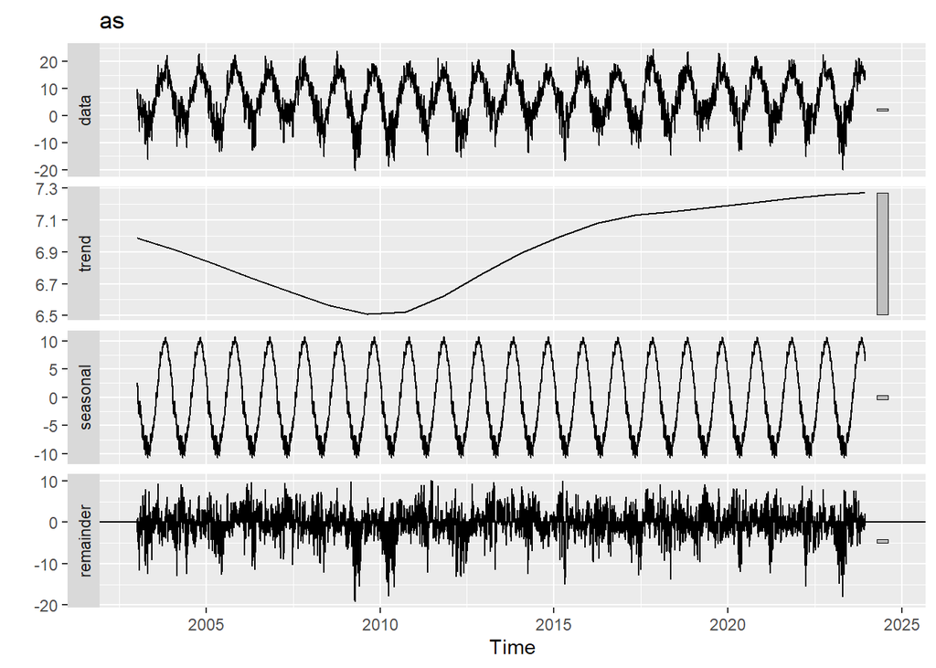

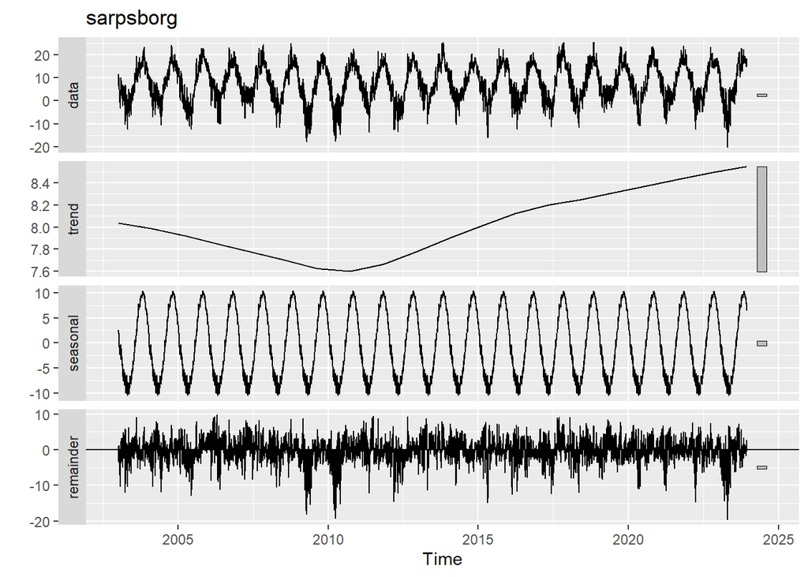

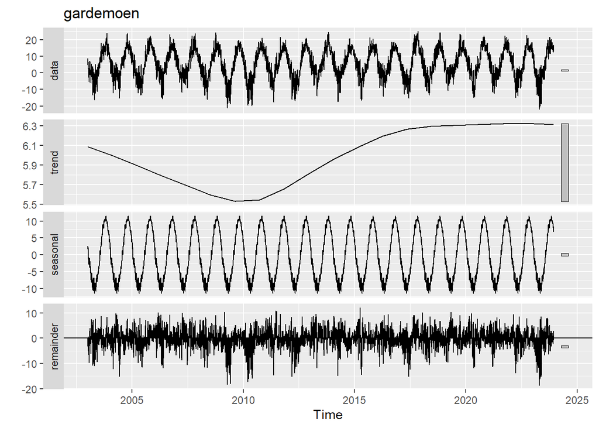

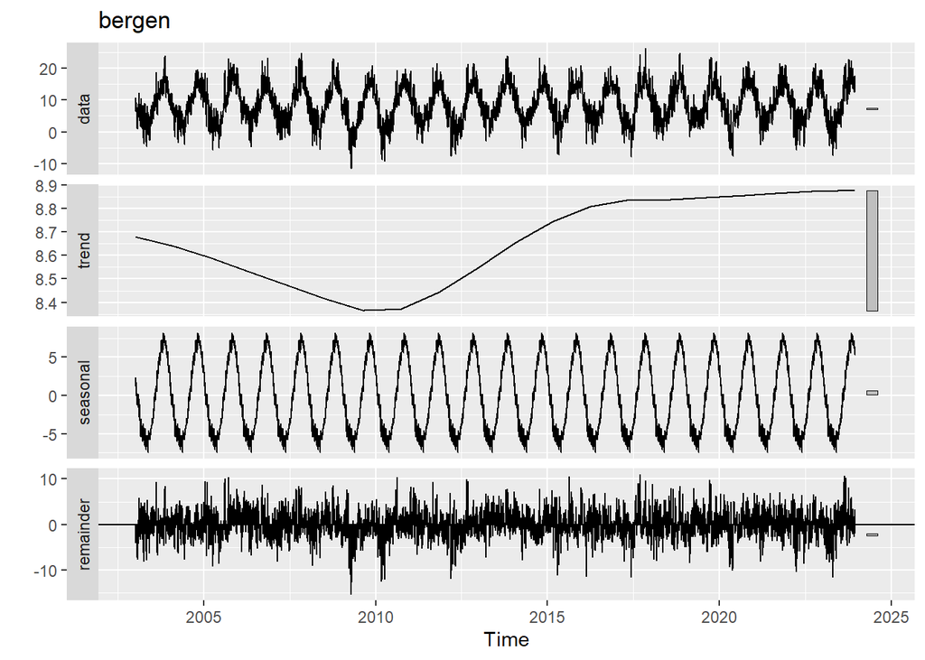

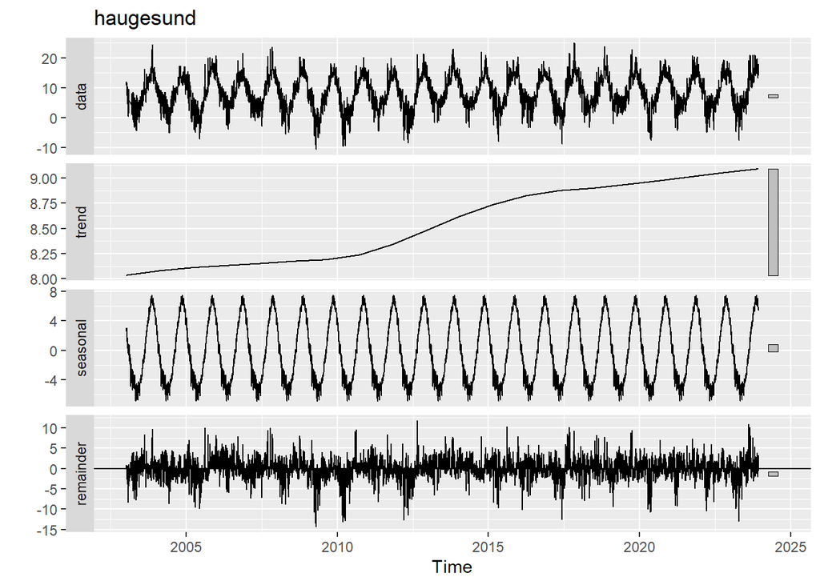

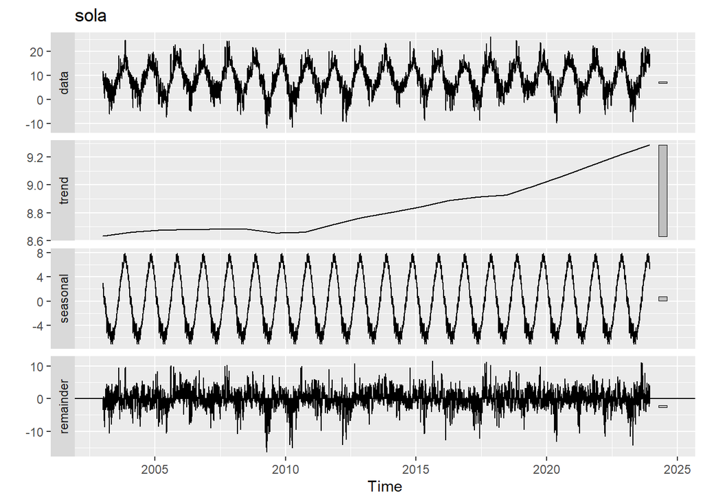

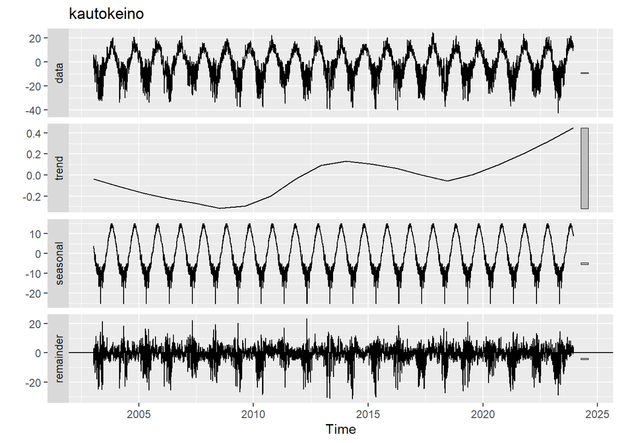

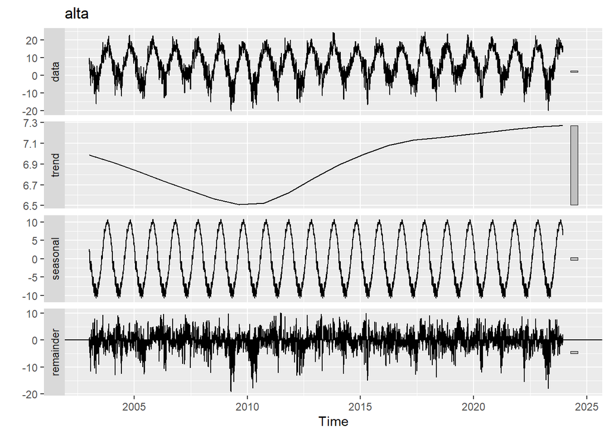

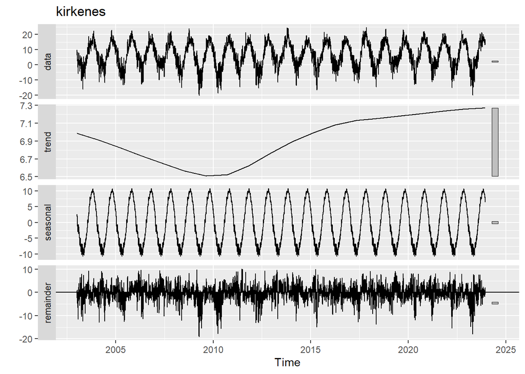

```r
places = c("as", "sarpsborg", "gardemoen", "bergen", "haugesund", "sola", "kautokeino", "alta", "kirkenes")
for (i in 1:9){
  stl_i <- stl(multivariate_ts[, i], s.window="periodic", t.window = 11*365, l.window = 365,  robust=TRUE)
  p <- autoplot(stl_i, main=places[i])
  print(p)
}
```

The quality of the STL results are equal for all stations. The seasonality and trend is well captured for all stations. The variance of the remainder seems to follow the variance of the data. Large variance in the timeseries, causes larger remainder.

```r
pc <- prcomp(multivariate_tsibble[, names(multivariate_tsibble)!="referenceTime"], scale=TRUE)
```

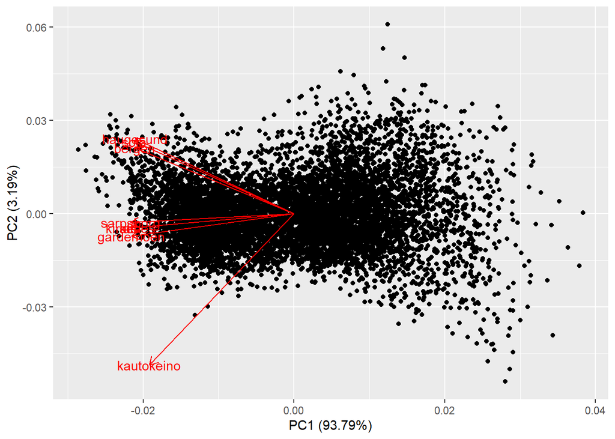

```r
autoplot(pc, loadings.label=TRUE)
```